```python
%%html
<link href='https://fonts.googleapis.com/css?family=Roboto' rel='stylesheet'>
<style>
body {
    font-family: 'Roboto', 'Helvetica', sans-serif;
    font-size: 12px;
}
</style>
```

# **What's up r/Phililppines? Topic Modelling on Reddit Philippines**

```python
import pandas as pd
import numpy as np
import matplotlib.pyplot as plt
import matplotlib.patches as mpatches
import altair as alt
import seaborn as sns
import re
import os
import json
import sqlite3
import requests
from datetime import datetime, timedelta
from bs4 import BeautifulSoup
from numpy.testing import assert_equal
from pywaffle import Waffle

import plotly.graph_objects as go
from plotly.subplots import make_subplots
from nltk.probability import FreqDist

from PIL import Image

from IPython.display import HTML, display
import pprint

import warnings
warnings.filterwarnings('ignore')

# for wordclous
from PIL import Image
from wordcloud import WordCloud, STOPWORDS
```

```python
# Create toggle cell button
font = "Roboto-Regular.ttf"
pp = pprint.PrettyPrinter(indent=4, width=100)


HTML('''
<style>
.output_png {
    display: table-cell;
    text-align: center;
    vertical-align: middle;
}

.output {
    display: flex;
    align-items: left;
    text-align: justify;
}

</style>


<script>
code_show=true;
function code_toggle() {
 if (code_show){
 $('div.input').hide();
 } else {
 $('div.input').show();
 }
 code_show = !code_show
}
$( document ).ready(code_toggle);
</script>
<form action="javascript:code_toggle()"><input type="submit"
value="Click here to toggle on/off the raw code."></form>
''')
```

```python
class reddit():


    def __init__(self, fname_date):
        """Initialize reddit object from the file

        Assumptions:
        source directory: fixed as defined
        filename: fixed as defined
        """
        fp_dir = f"./data_postprocessed/post_RS_" + fname_date + ".pkl"
        r_json = pd.read_pickle(fp_dir)
#         print(fp_dir)

        self.fname_date = fname_date
        self.svd = r_json['svd_model']
        self.lsa_data = r_json['lsa_data']
        self.vectorizer = r_json['vectorizer']
        self.titles = r_json['titles']

        # comments count +1 including themselves
        # this is to compensate for posts w/o comments
        self.titles['comments'] = self.titles['No. Comments']+1

        self.feature_names = self.vectorizer.get_feature_names()
        self.Sigma = self.svd.singular_values_
        self.V_T = self.svd.components_.T
        self.nssd = self.svd.explained_variance_ratio_

        # Map weights and words associated for each SV / topic:
        svs_words = []
        for i, comp in enumerate(self.svd.components_):
            terms_comp = zip(self.feature_names, comp)
            sorted_terms = sorted(terms_comp, key = lambda x:x[1], reverse=True)[:7]
            p = []
            for t in sorted_terms:
                p.append(t[0])
            svs_words.append(" ".join(p))

        func = lambda x: np.asarray(x) * np.asarray(self.titles['comments'])
        titles_topics = pd.DataFrame(self.lsa_data)
        titles_topics = titles_topics.apply(func)
        all_results = titles_topics.join(self.titles)
        monthly_results = all_results.groupby('month').sum()

        n_rows = self.lsa_data.shape[1]
#         per_month = monthly_results.iloc[0].to_frame().iloc[:n_rows,:]
        self.per_month = monthly_results.iloc[0].to_frame().iloc[:-6,:]
        self.per_month.columns = ['sv_sum']
        self.per_month = self.per_month.reset_index()
        self.per_month = self.per_month.sort_values(by='sv_sum', ascending=False)

    def plt_plots(self, plt_list, plt_title = "DEFAULT"):
        """Plot provided SV indeces

        Input:
        -----
        plt_list: list of indexes to plot
            range from 0 up to max number of svs

        Return:
        -------
        None, plots the graphs
        """
        for each in plt_list:
            i = self.per_month.iloc[each,0]
            fig, ax = plt.subplots()
            plt.title("hello, "+plt_title )
            order = np.argsort(np.abs(self.V_T[:, i]))[-10:]
            ax.barh([self.feature_names[o] for o in order], self.V_T[order, i])
            ax.set_title(f'SV{i+1}')
            plt.show()

    def plt_popular(self, plt_list, plt_color, plt_title = "DEFAULT"):
        """Plot top 8 words that describe the popular topics

        Input:
        -----
        plt_list: list of indexes to plot
            range from 0 up to max number of svs

        Return:
        -------
        None, plots the graphs
        """
        import seaborn as sns
        import matplotlib.pyplot as plt

        sns.set_theme(style="whitegrid")
        sns.set_color_codes("pastel")
        f, axes = plt.subplots(3,3, figsize=(18,12))
        f.suptitle(f'{plt_title}')

        for each in plt_list:
            x = each//3
            y = each%3

            # Prepare Dataset
            i = self.per_month.iloc[each,0]
            order = np.argsort(np.abs(self.V_T[:, i]))[-10:]
            z = pd.DataFrame({
                'A': self.V_T[order, i],
                'B': [self.feature_names[o] for o in order],
                'C': np.abs(self.V_T[order, i])
            })
            z = z.sort_values(by='C', ascending=False)

            axes[x,y].set_title(f"RANK {each+1} : SV{i+1}")
#             a = sns.barplot(x="A", y="B", data=z, color="grey", ax=axes[x,y])
            a = sns.barplot(x="A", y="B", data=z, color=plt_color[each], ax=axes[x,y])
            a.set(ylabel="", xlabel="")

        plt.subplots_adjust(left=0.1, bottom=0.1, right=0.9, top=0.9, wspace=0.4, hspace=0.4)
```

```python
# INITIALIZE for EDA of per month
# parameter = YYYY-MM
jan = reddit('2020-01')
feb = reddit('2020-02')
mar = reddit('2020-03')
apr = reddit('2020-04')
plt_default = ['grey', 'grey', 'grey', 'grey', 'grey', 'grey', 'grey', 'grey']
plt_color = ['blue', 'red', "grey","grey","grey","grey",'blue','blue', 'grey']
```

```python
# RETRIEVE data on the whole dataset initial exploration

# data_ex = [x_words, x_text, all_dates, all_subscribers, all_18]
fp_dir = f"./data_postprocessed/all_dates.pkl"
data_ex = pd.read_pickle(fp_dir)
x_words = data_ex[0]
x_text = data_ex[1]
all_dates = data_ex[2]
all_subscribers = data_ex[3]
```

# Executive Summary

Reddit is a social media forum with an emphasis on communities called subreddits. Worldwide, there are over 52 million daily active users on the site. In the Philippines, there are over 73 million (67% of the population) Filipinos with access to the internet so there should be no surprise that there are Filipino Reddit users who reside in their own subreddit community: r/Philippines. The subreddit was created on July 4, 2008 and at the time of writing, has over 614 thousand members, produces over 4733 comments a day, and 129 posts a day. This report aims to find out what are the frequent topics in reddit Philippines to find potential insights that could help grow the community.

Implementing LSA to reddit Philippines leads to show the repetitive nature of reddit Philippines’ text posts. As a subreddit, it may not create much of a community but rather seems to serve as an aggregator for news. Moderators of the subreddit might want to encourage their communities to feature a wider variety of topics rather than repetitive posts if they want to entice more members to join their community.

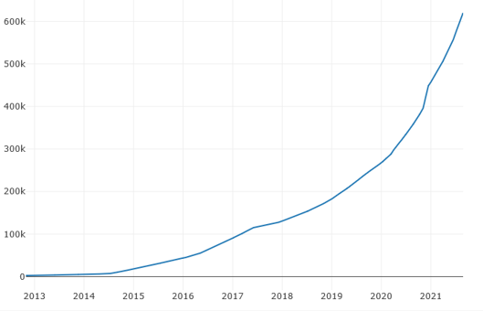

#### Figure 1. Number of Reddit Subscribers (source: https://subredditstats.com/r/philippines)

# Problem Statement

Despite being one of the biggest online communities on the internet, the specific subreddit for the Philippines only has 614,000 members, which is equal to less than 1% of Filipinos with an internet access. What are the major groupings of topics discussed in subreddit: Philippines per month? This report aims to model the frequently discussed topics in Reddit Philippines to get a pulse check on this digital community and could potentially hold insights in helping make the subreddit more inclusive to other Filipinos to be able to grow and expand the community.

# Data Description: Reddit

Each reddit file contains a dictionary object with a single key as ‘RS_YYYY-MM’ with the list of all reddit posts for that month as its value. Each reddit post is represented as a dictionary having 82 keys which corresponds to elements of a reddit post, for example: post title, number of comments, crossposts, etc.

For this study, to be able to gather information on popular topics and themes being discussed, we are limiting the scope to focus on the post title which is allowed to be up to 300 characters long. Although limited, a post title is relatively short, users provide key words to get the right attention to the other readers in the community and we think can provide an overview that can represent the topic of the post. Users are allowed to respond to each post through comments which can be up to 10,000 characters long. Each post also has an accompanying score called upvotes that corresponds to a vote of approval from users. For the purpose of this study, we are only considering the number of comments that respond to the post rather than the score because we want to focus on engagement in the form of discussions among users.

# Methodology

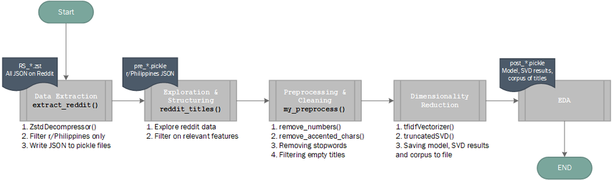

#### Figure 2. Methodology Flowchart

## Data extraction

The datasets are webscrapes of monthly post titles and details from each post from all the subreddits on Reddit.com which were taken from AIM’s public dataset collection located in `/mnt/data/public/reddit/submissions`. These are saved as dictionary strings in text files compressed as .zst files with the file name format of `RS_YYYY-MM` which indicates each file was a monthly collection of post information. The SLT decided to limit its scope to the years of 2019 to 2020 as these are the most recent data available.

Due to the large file sizes, decompression was an additional layer of complexity for our SLT because it was not possible to decompress and load the full file without exceeding the kernel memory. We used `ZstdDecompressor` from the zstandard package that allowed us to decompress the file at requests of a specified byte size that is within the kernel limitations. However there was no assurance that each requested and decompressed chunk was a complete json object and so there was required logic to piece together objects that may have been split among several chunks. For this, we leveraged available snippets provided online and by professors we consulted. Throughout the extraction, we paid attention to filter and store only the reddit entries that were relevant to the study to manage the volume during runtime. As such, we only needed to collect a manageable number of json objects at around 6,000 to a maximum of 11,000 objects from each file source file. All above steps were included in the function `extract_reddit` whose output was saved as pickle files in subfolder `/data_preprocessed` with filename format `RS_YYYY-MM.pkl`. The process of parsing the data from 2019 to 2019 into pickle files took around 4 hours to run.

## Exploration and Structuring

A second function, `reddit_titles()` was created to facilitate the reading of each of the month’s pickle files to create smaller json objects with keys that may be relevant to our study:

| Key | Description |
| --- | --- |
| title | Title of the post |
| subreddit_subscribers | number of reddit subscribers at the time |
| created_utc | datetime of creation date |
| num_comments | number of comments |
| over_18 | boolean |

## Data Preprocessing

As with any topic modeling, it is important to ensure that we are working on a dataset that contains and is reduced to meaningful words. We performed the following steps in our function `my_preprocess()` that would run each text processing function and returns our corpus of cleaned post titles along with other information about our dataset. It is performing the following steps:

1. `remove_numbers()` removes symbols and numbers from the titles through regex.
2. `remove_accented_chars()` replaces accented characters using `unicodedata.normalize`.
3. Remove stopwords in both English and Filipino
   - To remove english stopwords, we simply used `.words` from the `stopwords` package. The `TfidfVectorizer` later on also performs additional removal of english stopwords
   - The titles in our dataset were written in Filipino language as well. Unfortunately, there are no established stop words for the Filipino language so we used multiple sources to build stop words for our purpose. The main source we used is Frequency analysis by Jasper Kyle Catapang on the entire Tagalog Wikipedia corpus (https://nlpinas.org.ph/open_data/). Its top_1000_tl.csv file contains the top 1000 words and count of occurrences in the Tagalog Wikipedia corpus and we selected the words that appeared in more than 70% of all the words in the whole corpus. We arrived at 189 stop words for Filipino language.

Our function also performs tokenization through function `remove_punctuation()` for initial EDA to have an idea of the number of words in total in our dataset as below:

Original scope of 16 months from January 2019 to April 2020:

- Total number of titles extracted: 121,767
- Total words: 719,883
- Unique words: 57,578

We later on decided on reducing our scope to a smaller volume to January to April 2020:

- Total number of titles extracted: 36,623
- Total words: 223,867
- Unique words: 29,546

Early exploration of the words show that based on word count, Philippines is the most commonly used word. We, however, did not scope this out as a stop word because this can still give context to local issues and topics.

```
total words:  223867
```

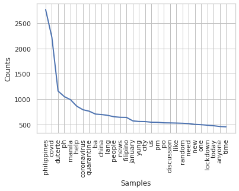

```python
# plot of word frequency
print("total words: ", len(x_words))
fdist = FreqDist(x_words)
fdist.plot(30,cumulative=False)
plt.show()
```

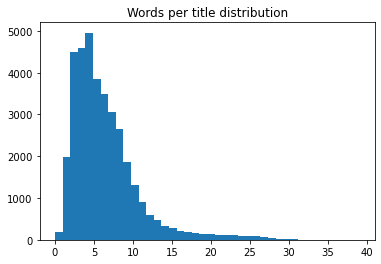

```python
title_count = [len(each) for each in x_text]
plt.hist(title_count, bins = 40)
plt.title("Words per title distribution")
plt.show()
```

A total of 36,440 titles from **36,623 Reddit post titles remain** (total of 183 removed):

| Month | Empty Titles | Remaining posts |
| --- | --- | --- |
| January | 33 | 7,292 |
| February | 19 | 6,682 |
| March | 64 | 11,422 |
| April | 67 | 11,044 |

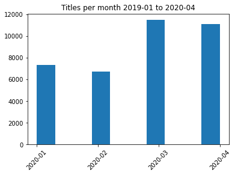

```python
plt.hist(all_dates)
plt.title("Titles per month 2019-01 to 2020-04")
plt.xticks(rotation=45)
plt.show()
```

As observed earlier in the whole dataset after cleaning, the range of number of words spans a 1 up to under 40 words. The most engagement through comments do not necessarily belong to long titles but rather happen with only at 4 words (stop words removed). This can show that user behavior may be more attracted to a concise title.

The number of comments have a few outliers that reach up to 6,000 comments in the month of March. Looking at the specific titles, those were main threads about Covid discussions. In that respect, we decided not to remove these outliers because they still are representative of the proportion of engagement on that subject matter.

Additionally, we checked the appearance of posts marked as Over 18, and have confirmed that this is very rarely happening. If this were happening very often, that would also make an interesting study on what topics are usually marked as such.

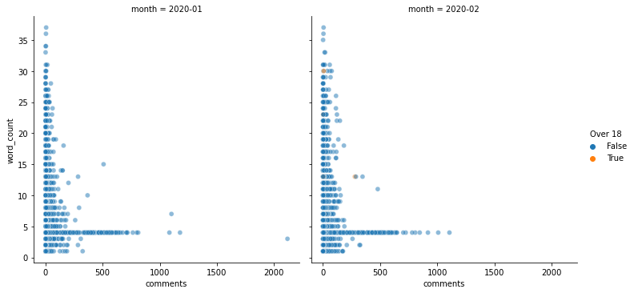

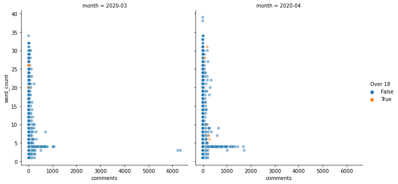

```python
sns.relplot(
    data=jan.titles.append(feb.titles), y="word_count", x="comments",
    col="month", kind="scatter", alpha=.5,
    hue ="Over 18"
)
sns.relplot(
    data=mar.titles.append(apr.titles), y="word_count", x="comments",
    col="month", kind="scatter", alpha=.5,
    hue ="Over 18",
);
```

## Dimensionailty Reduction

Now having a complete and clean list of reddit titles, we next want them to be represented as a matrix having each reddit title as the row while each column as the words. We opted for **Term Frequency-Inverse Document Frequency or TF-IDF** so that it provides a numerical value representative of the importance of each word with respect to the whole title (the higher, the more important). To reduce the number of features to specific topics, we went for **Latent Semantic Analysis or LSA** since this is appropriate for sparse matrices and can provide as an output mapping of which are words that are strongly and inversely related as guidance in identifying the topics.

### Vectorizing with `TfidfVectorizer`

Given that TfidfVectorizer also performs tokenization, here is our approach and results in tuning the parameters:

- Enabling stopwords for English: 166 words additionally removed
- Max_df had no change in the number of words since we have also already performed removal of stop words which is the goal of this parameter
- We focused on adjusting min_df in a way that reduced to the number of features that the next step, TruncatedSVD, could process.

### LSA with `TruncatedSVD`

One constraint we encountered was the number of features that TruncatedSVD can process. Due to this constraint, we limited the huge volume by:

- Performing vectorization and LSA on the dataset individually for each of the months in scope
- Increasing min_df to 15 (from ideal of 3) to reduce corpus
- Decrease TruncatedSVD parameter n_components to max of 700
- Decrease target explained variance from originally 90% to only 60%

Below are the resulting vectorized corpus for each month after tuning that was accepted by TruncatedSVD:

| Month | Rows | Words | Result |
| --- | --- | --- | --- |
| All Months | 36,440 | 29,374 | Kernel died |
| Jan 2020 | 7292 | 402 |  |
| Feb 2020 | 6682 | 377 |  |
| Mar 2020 | 11422 | 728 |  |
| Apr 2020 | 11044 | 790 |  |

### Observations and final parameters

Below are the final parameters we used:

**Parameters for TFIDF**

| Parameter | Value | Comments |
| --- | --- | --- |
| stop_words | 'english' | Enable removal of stop words from English dictionary |
| max_features | 50_000 | As high as possible |
| max_df | 0.9 | Remove words appearing in more than 90% of titles |
| min_df | 15 | Remove words appearing in less than 15 titles |
| smooth_idf | True | Prevents zero division by adding 1 to doc frequencies |

**Parameters for LSA**

| Parameter | Value | Comments |
| --- | --- | --- |
| n_components | 700 | whichever is less between 700 or (number of words - 1) |
| algorithm | randomized | documentation says this is faster processing |
| n_iter | 100 |  |
| random_state | 122 |  |

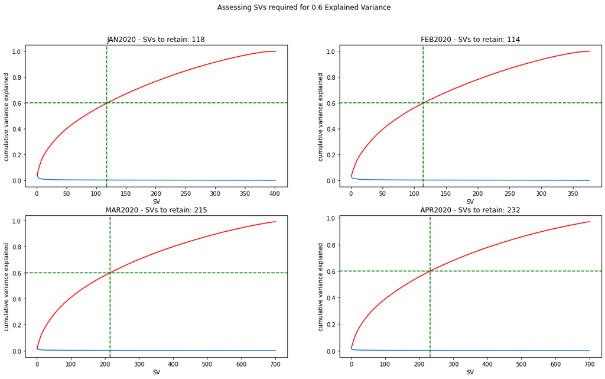

```python
# what is your ideal variance explained?
my_var = 0.6

# using svd.explained_variance_ratio_
svs = np.array(jan.nssd.cumsum())
my_svs = np.where(svs>= my_var)[0][0]
nssd = jan.svd.explained_variance_ratio_

fig, axes = plt.subplots(nrows=2, ncols=2, figsize=(18,10))
fig.suptitle(f"Assessing SVs required for {my_var} Explained Variance")
axes[0,0].set_title(f"JAN2020 - SVs to retain: {my_svs}")
axes[0,0].plot(range(1, len(jan.nssd)+1), jan.nssd, '-', label='individual')
# axes.set_xlim(0, len(jan.nssd)+1)
axes[0,0].set_xlabel('SV')
axes[0,0].set_ylabel('variance explained')
# axes[0,0] = axes.twinx()
axes[0,0].plot(range(1, len(jan.nssd)+1), jan.nssd.cumsum(), 'r-', label='cumulative')
axes[0,0].axhline(my_var, ls='--', color='g')
axes[0,0].axvline(my_svs, ls='--', color='g')
axes[0,0].set_ylabel('cumulative variance explained');

svs = np.array(feb.nssd.cumsum())
my_svs = np.where(svs>= my_var)[0][0]
nssd = feb.svd.explained_variance_ratio_

axes[0,1].set_title(f"FEB2020 - SVs to retain: {my_svs}")
axes[0,1].plot(range(1, len(feb.nssd)+1), feb.nssd, '-', label='individual')
# axes.set_xlim(0, len(jan.nssd)+1)
axes[0,1].set_xlabel('SV')
axes[0,1].set_ylabel('variance explained')
# axes[0,0] = axes.twinx()
axes[0,1].plot(range(1, len(feb.nssd)+1), feb.nssd.cumsum(), 'r-', label='cumulative')
axes[0,1].axhline(my_var, ls='--', color='g')
axes[0,1].axvline(my_svs, ls='--', color='g')
axes[0,1].set_ylabel('cumulative variance explained');

svs = np.array(mar.nssd.cumsum())
my_svs = np.where(svs>= my_var)[0][0]
nssd = mar.svd.explained_variance_ratio_

axes[1,0].set_title(f"MAR2020 - SVs to retain: {my_svs}")
axes[1,0].plot(range(1, len(mar.nssd)+1), mar.nssd, '-', label='individual')
# axes.set_xlim(0, len(jan.nssd)+1)
axes[1,0].set_xlabel('SV')
axes[1,0].set_ylabel('variance explained')
# axes[0,0] = axes.twinx()
axes[1,0].plot(range(1, len(mar.nssd)+1), mar.nssd.cumsum(), 'r-', label='cumulative')
axes[1,0].axhline(my_var, ls='--', color='g')
axes[1,0].axvline(my_svs, ls='--', color='g')
axes[1,0].set_ylabel('cumulative variance explained');

svs = np.array(apr.nssd.cumsum())
my_svs = np.where(svs>= my_var)[0][0]
nssd = apr.svd.explained_variance_ratio_

axes[1,1].set_title(f"APR2020 - SVs to retain: {my_svs}")
axes[1,1].plot(range(1, len(apr.nssd)+1), apr.nssd, '-', label='individual')
# axes.set_xlim(0, len(jan.nssd)+1)
axes[1,1].set_xlabel('SV')
axes[1,1].set_ylabel('variance explained')
# axes[0,0] = axes.twinx()
axes[1,1].plot(range(1, len(apr.nssd)+1), apr.nssd.cumsum(), 'r-', label='cumulative')
axes[1,1].axhline(my_var, ls='--', color='g')
axes[1,1].axvline(my_svs, ls='--', color='g')
axes[1,1].set_ylabel('cumulative variance explained');
```

## Post Processing

Information from pre-processing as well as after dimensionality reduction are stored in pickle files for purpose of EDA and visualization. All these are stored in the folder `./data_postprocessed`:

- `all_dates.pkl` - contain list of words, dates, subscribers and general information about all four months data combined.
- `post_RS_2020-01.pkl`, `post_RS_2020-02.pkl`, `post_RS_2020-03.pkl`, `post_RS_2020-04.pkl` - one file for each month containing each month's dataframe of title and comment numbrs, tokenized titles, svd model, truncated matrices that are used in EDA. We have also created class `reddit()` that stores relevant information and performs relevant steps required to interpret results of the LSA.

# Exploratory Data Analysis

Popularity of the topic, in the context of Reddit, may be topics where there are many posts that are created. However there are also instances where a single post may engage a lot of users commenting on it. To represent this behavior in our analysis, we leverage on an available field `num_comments` and use that to magnify the weight of SVs on them.

Thus, popularity is not only driven by the number of posts related to the topic but we also consider that are related to posts having very high number of comments are considered more popular. Some posts may not have any comments but the mere creation of the post should be reflected in the popularity weight. Popularity weight = number of comments + 1 to include the original post. Ie, a post w/o comments counts as 1, while a post with 10 comments counts as 11.

**Procedure**

1. After performing `tfidVectorizer` and `TruncatedSVD`, we have the new SVs and weights that represent each of the original titles.
2. We ensure that `num_comments` are not zero 0 by increasing all values by 1 for all entries to represent the activity from the original post as well even if no one commmented on it.
3. We will simply multiple the number of comments to the resulting transformed table.
4. We get the sum value for each SV in each month. The higher the sum, the more popular the topic reprsented by the SV is.

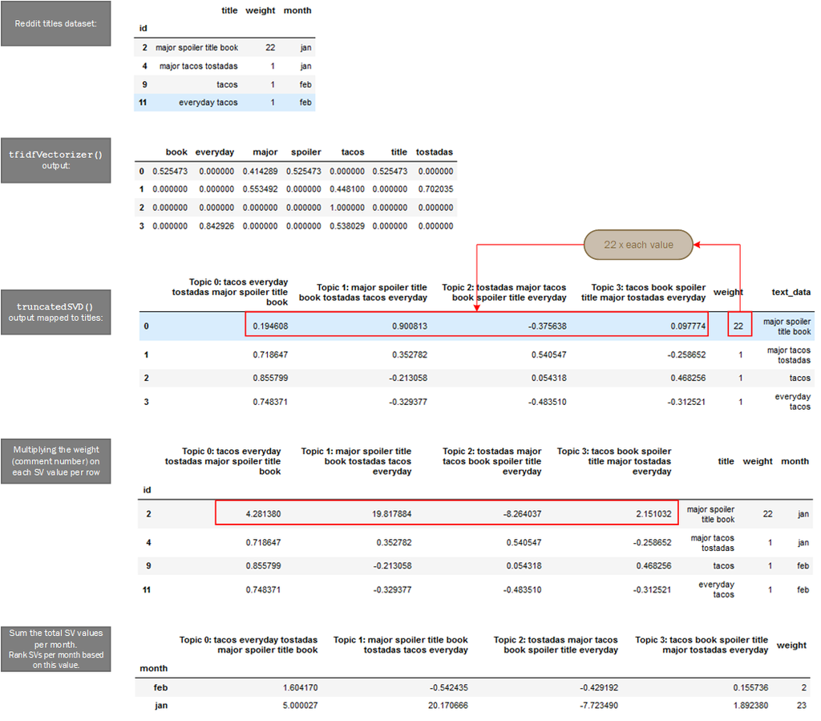

#### Figure 3. Determining popularity of topics per month

We then looked at the SVs with the highest values for each month and display top 10 words that contribute to that SV so that we can try to surmise the theme/topic it is referring to. In our analysis below we looked at each one and describe those specially with distinguished features.

In some cases there is a bit of challenge to define/articulate the topic that is described by the words and their components. We have some learnings and recommendation in the next section on how this can be improved.

[figure not shown]

```python
def plot_cloud(wordcloud):
    # Set figure size
    plt.figure(figsize=(30, 20))
    # Display image
    plt.imshow(wordcloud)
    # No axis details
    plt.axis("off");

# Import image to np.array
mask = np.array(Image.open('comment.png'))

# Generate wordcloud
wordcloud = WordCloud(width = 3000, height = 2000, random_state=1,
                      background_color='white', colormap='Set1',
                      collocations=False, stopwords = STOPWORDS,
                      mask=mask)
wordcloud.generate(" ".join(x_words))

# Plot
plot_cloud(wordcloud)
```

#### Figure 4. What are the commonly used words seen in r/Philippines Reddit titles?

We created a wordcloud from the corpus across January to April 2020 with the simple count of frequency the word appeared on the titles. We can see that **r/Philippines** community on high level are about current events those months that were happening with respect to politics, covid, and quarantine. It is nice to see that despite all the words related to issues at the time, there are also positive-oriented words like help, good, prayer, positive among it.

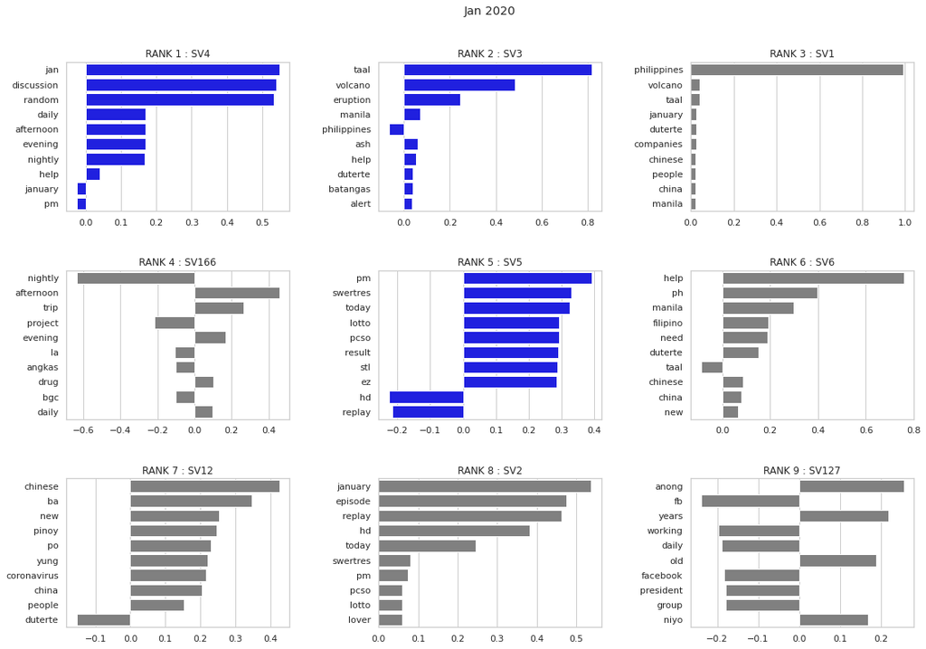

```python
jan.plt_popular(range(9),
                ['blue', 'blue', 'grey', 'grey', 'blue',
                 'grey', 'grey', 'grey', 'grey'],
                plt_title="Jan 2020")
```

#### Figure 5. January 2020

For January, **SV4 (rank 1)** has heavy weights in the features: jan, discussion, random with additional positive weights in the daily, afternoon, evening, nightly features. This SV was probably born out of r/Philippines daily random discussion threads. This thread is created by moderators to foster random discussions in the subreddit and is consistently present, which explains its presence as an SV. Each month has its own corresponding SV similar to this, so to reduce redundancy we’ll only mention that particular SV if there is anything of interest to note.

**SV3 (rank 2)** has the features: taal, volcano, eruption weighing heavily on the SV probably because the taal volcano eruption happened during this month. Lesser features which weighed positively includes: manila, ash, batangas, alert, and duterte. This topic was probably caused by the Taal Volcano eruption which resulted in the spread of ashes over the Luzon region.

**SV5 (rank 5)** SV has weights in pm, swertres, toda, pcso, lotto, result, stl, ez. Presumably, at the time, the jackpot prize for the PCSO lotto was large and was capturing attention.

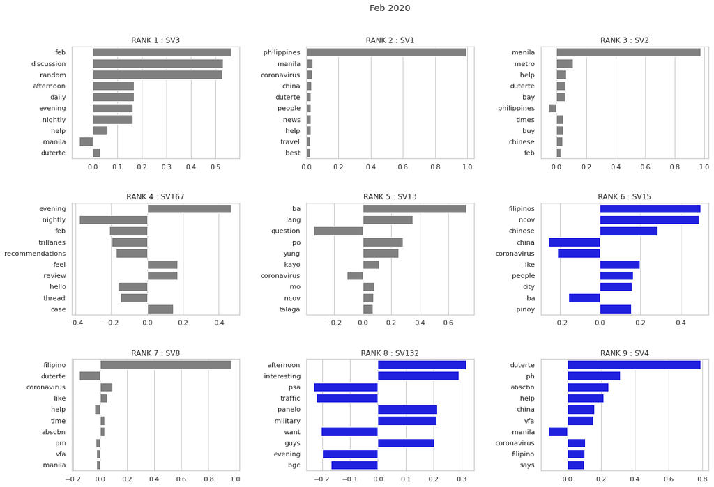

```python
feb.plt_popular(range(9),
                ['grey', 'grey', 'grey', 'grey', 'grey',
                 'blue', 'grey', 'blue','blue'],
                plt_title="Feb 2020")
```

#### Figure 6. February 2020

**SV15 (rank 6)** is interesting because its positive weights come from the features: filipinos, ncov, chinese, like, people, city, pinoy but has negative weights in china, coronavirus, ba. It’s apparent that this topic refers to the coronavirus from China. Stemming could have avoided the differentiation between chinese and china but we opted to avoid stemming due to possible modifications to Filipino words.

**SV132 (rank 8)** with heavy weights in: afternoon, interesting, panelo, military, guys. Possibly because the Presidential Spokesperson at the time, Salvador Panelo, announced that President Duterte moved to scrap the Visiting Forces Agreement (VFA) with the United States and its military.

**SV4 (rank 9)** has heavy weights in: duterte, ph, abscbn, help, china, vfa, coronavirus, filipino, and says. At the time these were all news headlines regarding the Philippines, Duterte, China and the Coronavirus, the Visiting Forces Agreement, the ABSCBN franchise renewal issue.

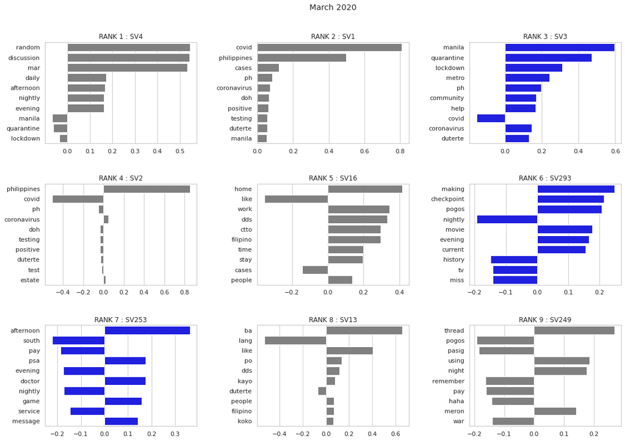

```python
mar.plt_popular(range(9),
                ['grey', 'grey', 'blue', 'grey', 'grey',
                 'blue', 'blue', 'grey','grey'],
                plt_title="March 2020")
```

#### Figure 7. March 2020

**SV3 (rank 3)** has weights in the features: manila, quarantine, lockdown, metro, ph, community, community, help. This is probably because of the Enchanced Community Quarantine lockdown that affected Filipinos in Metro Manila.

**SV293 (rank 6)** has weights in the features: making, checkpoint, pogos, movie, evening, current. Possibly because of the suspension of pogos during this month, or even possibly Pokemon Go.

**SV253 (rank 7)** has weights in the features: afternoon, psa, doctor, game, message. Possibly, this topic involves the PSA report on unemployment due to covid, which was released at the time.

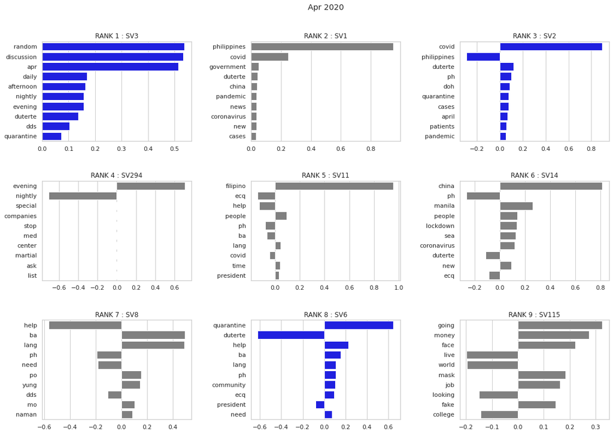

```python
apr.plt_popular(range(9),
                ['blue', 'grey', 'blue', 'grey', 'grey',
                 'grey', 'grey', 'blue', 'grey'],
                plt_title="Apr 2020")
```

#### Figure 8. April 2020

**SV3 (rank 1)** has weights in random, discussion, april, daily, afternoon, nightly, evening, duterte, dds, and quarantine. We included this SV due to the addition of duterte, dds, and quarantine, which was previously not present in the analysis of the previous months. There may have been increased frequency of political discussions during this month.

**SV2 (rank 3)** has weights in covid, duterte, ph, doh, quarantine, cases, april, patients, pandemic, which indicates a huge volume of posts concerning the pandemic in the Philippines even outside of the random discussion thread.

**SV6 (rank 8)** has weights in quarantine, help, ph, community, ecq, need which indicates that some users may be asking for help from other users on the reddit platform.

# Conclusion

Looking at the *popular topics* based on the output SVs, it’s very clear that the top posts on reddit Philippines are very influenced by local news. For example, January 2020 had mentions of the Taal Volcano Eruption and PCSO lotto. February 2020 has features corresponding to the scrapping of the VFA and the coronavirus. It seems that news articles are heavily posted, reposted, and commented on in reddit Philippines. The implementation of LSA on reddit Philippines led to SVs with similar recurring features revolving around philippines, duterte, china, covid19, etc.

In hindsight, analyzing reddit using titles alone would miss out on content from posts that didn’t elaborate using their titles, used emoticons as titles, or were primarily picture posts. Given additional time, the group could implement this methodology to analyze post comments to get a deeper understanding of the users in reddit Philippines.

With our methodology of analyzing post titles as our scope, it felt justified for us to add an aspect of weight using the number of replies to the post as posts like these might not be uncovered if they were overshadowed by multiple posts with repeated topics. Our process might be beneficial to deploy in forum-type communities where posts have corresponding titles and with a measurement of engagement such as comment counts.

# Recommendations

For moderators of the subreddit, the extracted themes and topics may urge them to encourage their communities to feature a wider variety of topics rather than repetitive posts.

For other users who may be interested to join r/Philippines, this can provide a preview of what this subreddit community most focuses on which may attract or dissuade them from joining this subreddit.

With respect to the methodology, using Reddit titles alone has its limitation because of the number of words that a user can express the message. Including comments could provide more meaningful themes and topics from the reddit posts. Additionally, we noticed that user on the platform conveys their messages in combination of media such as the use of emoticons and images in addition to words which, when included, can provide more context into their posts.

The study can be further improved by applying more advanced text processing techniques:

1. Better Text processing: performing lemmatization could provide better creation of the corpus to avoid representing the same root word in different tenses or forms.
2. Working with bilingual dataset also presented its own challenges because of the lack of language specific NLP functions available. Furthermore, translation of text to a single language would be ideal before proceeding with vecotirzation and LSA to have ability to link same word today that is represented separately in different languages
3. Using bi-grams may additionally provide more contextual insight between connected words
4. Explained variance was not as high as planned (settled for 60%, planned 90%) and this means there are more losses in representing the original dataset. If the kernel memory allows, or through other functions that allow to process at smaller volumes, we may achieve a more meaningful summary of topics and themes at a much higher explained variance.

# Acknowledgement and References

- https://www.oberlo.com/blog/reddit-statistics
- https://subredditstats.com/r/philippines
- https://pushshift.io/api-parameters/
- https://www.programcreek.com/python/example/124808/zstandard.ZstdDecompressor
- https://scikit-learn.org/stable/modules/generated/sklearn.feature_extraction.text.CountVectorizer.html
- https://www.datacamp.com/community/tutorials/text-analytics-beginners-nltk
- https://www.freecodecamp.org/news/an-introduction-to-bag-of-words-and-how-to-code-it-in-python-for-nlp-282e87a9da04/
- https://towardsdatascience.com/nlp-building-text-cleanup-and-preprocessing-pipeline-eba4095245a0
- https://towardsdatascience.com/topic-modeling-and-latent-dirichlet-allocation-in-python-9bf156893c24
- https://www.kaggle.com/shivampanwar/tutorial-lda-vs-pca-and-topic-modelling-using-lda
- https://www.geeksforgeeks.org/removing-stop-words-nltk-python/
- https://towardsdatascience.com/topic-modeling-articles-with-nmf-8c6b2a227a45
- Wordcloud mask from: https://www.kaggle.com/aashita/masks